# College Majors, Employment Rates, and Unemployment Rates

Fernando Careaga and Hannah Kantor-O’Neil

2017-04-04

# Introduction

Ever wondered what type of majors are the most popular for undergraduates across America? Ever wondered how much more money a certain degree can help you earn? Or ever thought about what the likelihood of finding employment after college with your degree is? Ever wondered if either male or female earn more? This vignette is based on a collection of 173 majors in 16 different major categories and their employment, unemployment, and median salaries based on majors. The following information was gathered and compiled by the American Community Survey. In this vignette we take a look at several graphs that break down and answer the questions listed above. With each graph there will be a comprehensive discussion explaining why the graphs look the way that they look.

This vignette is based on data collected for the 538 story entitled “This Economic Guide to Picking a College Major” by Ben Casselman available [here](https://fivethirtyeight.com/features/the-economic-guide-to-picking-a-college-major/).

First, we loaded the required packages to reproduce the analysis.

```r
library(fivethirtyeight)
library(dplyr)
library(ggplot2)
library(readr) # Used for reading in from a spreadsheet
library(knitr)
library(forcats)
```

Next, we loaded data which categorizes different `major_category`’s into `division`s and then joined with this data.

```r
divisions <- read_csv("data/divisions.csv")
college_with_divisions <- inner_join(x = college_all_ages,
                                     y = divisions,
                                     by = "major_category")
```

To avoid confusion, we also rename the `median` variable in `college_with_divisions` as `q2` since `median()` is a function in R:

```r
college_with_divisions <- college_with_divisions %>%
  rename(q2 = median)
```

# Total Number of Majors in Universities Across America

In this first graph we are looking at the major categories within the `college_all_ages` data frame and how many majors are included in each grouping. We use the `fct_infreq()` and `fct_rev` functions in the `forcats` package to sort the bars in order of `count`.

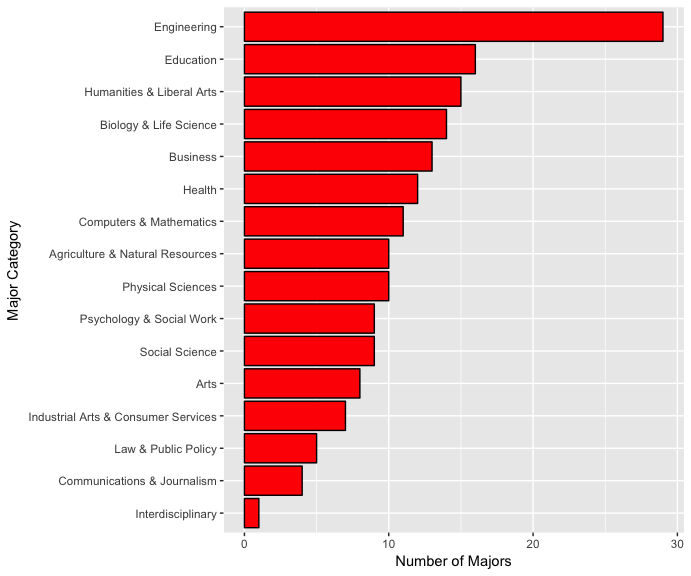

```r
college_all_ages <- college_all_ages %>%
  mutate(major_category = major_category %>% fct_infreq() %>% fct_rev())
ggplot(data = college_all_ages,
       mapping = aes(x = major_category)) +
  geom_bar(fill = "red", color = "black") +
  coord_flip() +
  labs(x = "Major Category", y = "Number of Majors")
```

It is interesting to think about there being so many different kinds of engineering majors but not very many majors in the fields at the bottom.

In the next graph, we are still looking at the `college_all_ages` data frame and taking an in depth look of the list of most popular majors to the least popular majors. Why might some majors be more popular than others? Let’s take a look at why engineering might be popular. Based on the fivethirtyeight article, a reason why this major category might be so popular is due to the variety of majors offered within that major category itself. For example, Engineering is a major category that offers Petroleum Engineering, Mechanical Engineering, Mining & Mineral Engineering, and Nuclear Engineering just to name a few. Whereas, the least picked major category, Interdisciplinary has a low variety of majors that students can choose from. Therefore, we can guess that major categories which are the most popular tend to be the ones that have a variety of disciplines within the major to choose from.

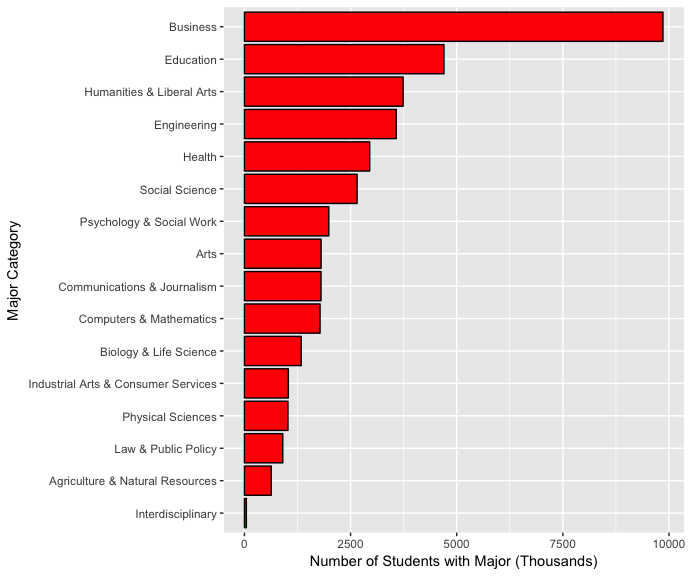

```r
group_major <- college_all_ages %>%
  group_by(major_category) %>%
  summarize(total_num = sum(total) / 1000) %>%
  mutate(major_category = fct_reorder(major_category, total_num))
ggplot(data = group_major, mapping = aes(x = major_category,
                                         y = total_num)) +
  geom_col(fill = "red", color = "black") +
  coord_flip() +
  labs(x = "Major Category", y = "Number of Students with Major (Thousands)")
```